# 第02章 数据分析利器：NumPy、pandas与 Matplotlib库

Python在机器学习领域的广泛使用很大一方面是因为其所提供的高效便捷的数据分析工具包, 最基础、最常用的就是

- numpy
- pandas
- matplotlib

## 2.1 numpy库基础

numpy,即Numerical Python

### 2.1.1 numpy库与数组

numpy库的主要特点是引入了`数组`的概念, 数组与列表类似

```python
import numpy as np # 使用np代替numpy, 方便之后调用该库中的函数

a = [1,2,3,4] # 创建列表a
b = np.array(a) #从列表a创建数组b, array就是数组的意思

print(a)
print(b)

print(type(a))
print(type(b))
```

```
[1, 2, 3, 4]
[1 2 3 4]
<class 'list'>
<class 'numpy.ndarray'>
```

```python
# 可以通过索引和切片访问列表和数组中的元素, 通过切片访问时起始索引左闭右开

print(a[1])
print(b[3])

print(a[0:3])
print(b[0:2])
```

```
2
4
[1, 2, 3]
[1 2]
```

列表和数组有着相同的索引机制，唯一的区别就是数组中的元素通过空格分隔，而列表中的元素通过逗号分隔

### 2.1.2 数组与列表的区别

为什么在数据分析中要使用数组而不使用列表？

- numpy专门用于数据处理，能支持一些数学运算

```python
c = a*2
d = b*2

print(c)
print(d)

# 同样为乘法运算, 列表只是复制元素, 数组是对每个元素做了乘法
```

```
[1, 2, 3, 4, 1, 2, 3, 4]
[2 4 6 8]
```

- 列表存储的是一维数据，数组能储存多维数据

  列表中的数据是一维的, excel工作表中的表格数据是二维的

```python
e = [[1, 2], [3, 4], [5, 6]]  # 列表里的元素为列表
f = np.array([[1, 2], [3, 4], [5, 6]])  # 创建二维数组的一种方式

print(e)
print(f)
```

```
[[1, 2], [3, 4], [5, 6]]
[[1 2]
 [3 4]
 [5 6]]
```

### 2.1.3 创建数组的几种方式

```python
b = np.array([1,2,3,4]) #创建一维数组

f = np.array([[1, 2], [3, 4], [5, 6]])  # 创建二维数组
```

除了直接键入外, 还有一些常用的创建数组的方式

np.arange()函数

numpy.arange([start = 0, ]stop, [step = 1, ]dtype=None)

```python
# 1个参数：参数值为终止值，起始值取默认值0，步长取默认值1，左闭右开
x = np.arange(5)
# 2个参数：第1个参数为起始值，第2个参数为终止值，步长取默认值1，左闭右开
y = np.arange(5, 10)
# 3个参数：第1个参数为起始值，第2个参数为终止值，第3个参数为步长，左闭右开
z = np.arange(5, 10, 0.5)

print(x)
print(y)
print(z, '\n')

print(np.arange(5, 10, 1.9, dtype=int))
print(np.arange(5, 10, 1, dtype=int))
print(np.arange(5, 10, 0.5, dtype=float))
print(np.arange(stop=5, start=6, step = -.1, dtype=float))
print(np.arange(5, 10, 0.99, dtype=int)) # 这里没有按照预想的输出[5 6 7 8 9], 似乎arange是先根据距离(stop - start)和步长(step)算出长度(length), 然后从起点开始, 每加一个步长向下取整(dtype = int), 循环长度(length)次
```

```
[0 1 2 3 4]
[5 6 7 8 9]
[5.  5.5 6.  6.5 7.  7.5 8.  8.5 9.  9.5]

[5 6 7]
[5 6 7 8 9]
[5.  5.5 6.  6.5 7.  7.5 8.  8.5 9.  9.5]
[6.  5.9 5.8 5.7 5.6 5.5 5.4 5.3 5.2 5.1]
[5 5 5 5 5 5]
```

```python
print(np.arange(5, 10, 0.99, dtype=int))

print(int((10-5)/.99) + 1)
print(len(np.arange(5, 10, 0.99, dtype=int)))
```

```
[5 5 5 5 5 5]
6
6
```

np.random随机数

- np.random.rand() 生成0到1之间的随机数
- np.random.randn() 生成标准正态分布（均值为 0，标准差为 1）随机数
- np.random.randint()
  - numpy.random.randint([low = 0,] high, [size = 1, ] dtype=int)

```python
print(np.random.rand(3))
print(np.random.randn(3))
print(np.random.randint(1,13,3))
```

```
[0.3182064  0.84848056 0.11698989]
[ 0.73941833 -2.03818035 -0.23895557]
[2 5 2]
```

可以利用创建一维数组的np.arange()函数和reshape()函数来创建二维数组

```python
a = np.arange(12).reshape(3,4)
print(a)
```

```
[[ 0  1  2  3]
 [ 4  5  6  7]
 [ 8  9 10 11]]
```

这些随机数生成的函数的size参数可以赋值为数组以创建多维数组

```python
print(np.random.randint(low = 1,high= 10,size=(3,3,3)), '\n')

print(np.random.randint(low = 1,high= 10,size=(3,4)))
```

```
[[[4 3 1]
  [4 6 6]
  [5 5 5]]

 [[6 8 4]
  [9 7 3]
  [4 3 9]]

 [[5 2 5]
  [4 1 3]
  [3 9 5]]]

[[3 6 2 4]
 [7 2 4 8]
 [3 5 3 8]]
```

## 2.2 pandas库基础

pandas

- 基于numpy库的库，名字源于panel data
- python版的excel
- 主要有series和dataframe两种数据结构
  - series类似于通过numpy库创建的以为数据，不同的是series对象不仅包含数值，还包括一组索引; 单独使用相对较少，主要使用dataframe数据结构
  - dataframe是一种二维表格数据结构
- 用于
  - 二维数据表格DataFrame的创建
  - Excel工作簿等文件的读写
  - 数据的选取与处理
  - 数据表拼接

### 2.2.1 二维数据表格DataFrame创建

```python
import pandas as pd

s1 = pd.Series(['丁一','王二','张三'])

print(s1)
```

```
0    丁一
1    王二
2    张三
dtype: object
```

```python
import pandas as pd

a = pd.DataFrame([[1,2],[3,4],[5,6]])

print(a)

a = pd.DataFrame([[1,2],[3,4],[5,6]], columns=['date','score'], index=['A','B','C']) #colummns代表列索引名称 index代表行索引名称

print(a)

a = pd.DataFrame()

date = [1,3,5]
score = [2,4,6]

a['date'] = date
a['score'] = score
a.index = ["A",'B','C']

print(a)

b = pd.DataFrame({'a': [1, 3, 5], 'b': [2, 4, 6]}, index=['x', 'y', 'z'])

print(b)

c = pd.DataFrame.from_dict({'a': [1, 3, 5], 'b': [2, 4, 6]}, orient  ="columns")#让字典键编程行索引，使用from_dict()函数将字典转换成dataframe，并同时设置orient参数为index，orient参数用于指定字典键为列索引还是行索引，默认值为columns

print(c)

c = pd.DataFrame.from_dict({'a': [1, 3, 5], 'b': [2, 4, 6]}, orient  ="index")

print(c)

print(c.T)#还可以通过dataframe的T属性对dataframe进行转置
```

```
   0  1
0  1  2
1  3  4
2  5  6
   date  score
A     1      2
B     3      4
C     5      6
   date  score
A     1      2
B     3      4
C     5      6
   a  b
x  1  2
y  3  4
z  5  6
   a  b
0  1  2
1  3  4
2  5  6
   0  1  2
a  1  3  5
b  2  4  6
   a  b
0  1  2
1  3  4
2  5  6
```

```python
import numpy as np, pandas as pd

d = pd.DataFrame(np.arange(12).reshape(3, 4), index=[1, 2, 3], columns =['A', 'B', 'C', 'D'])

print(d)

e = d.rename(columns={'A':"adan","B":"bert","C":"cell","D":"David"},index= {1:"first",2:"sec",3:"trd"})#rename()函数是用新的索引名新建一个dataframe，不改变a的内容，可以设置inplace参数为True来实现真正的重命名

print('d:', d)
print('e:',e)


d.rename(columns={'A':"adan","B":"bert","C":"cell","D":"David"},index= {1:"first",2:"sec",3:"trd"},inplace=True)

print('d:',d)

d.index.values

f = d.set_index('adan')#把行索引修改成某列的内容，也可以使用inplace参数

print('f:',f)
```

```
   A  B   C   D
1  0  1   2   3
2  4  5   6   7
3  8  9  10  11
d:    A  B   C   D
1  0  1   2   3
2  4  5   6   7
3  8  9  10  11
e:        adan  bert  cell  David
first     0     1     2      3
sec       4     5     6      7
trd       8     9    10     11
d:        adan  bert  cell  David
first     0     1     2      3
sec       4     5     6      7
trd       8     9    10     11
f:       bert  cell  David
adan
0        1     2      3
4        5     6      7
8        9    10     11
```

```python
#数据的选取与处理

import pandas as pd

data = pd.DataFrame([[1, 2, 3], [4, 5, 6], [7, 8, 9]], index=['r1',  'r2', 'r3'], columns=['c1', 'c2', 'c3'])

print(data)

#按列选取数据

a = data["c1"]

print('a:\n',a)#通过data['c1']选取一列是返回的是一个一维的series类型的数据

a = data[['c1']]

print('a:\n',a)

a = data[['c1','c3']]

print('a:\n',a)

#按行选取数据

a = data[1:3]#选取第2-3行的数据，序号从0开始，左闭右开

print('a:\n',a)

a = data.iloc[1:3]#推荐使用iloc方法来根据序号选取数据

print('a:\n',a)

c = data.iloc[-2]#选取单行必须用iloc方法，倒数第一行为-1
print('c:\n',c)

c = data.loc[['r1','r3']]#还可以通过loc方法根据行的名称来选取数据
```

```
    c1  c2  c3
r1   1   2   3
r2   4   5   6
r3   7   8   9
a:
 r1    1
r2    4
r3    7
Name: c1, dtype: int64
a:
     c1
r1   1
r2   4
r3   7
a:
     c1  c3
r1   1   3
r2   4   6
r3   7   9
a:
     c1  c2  c3
r2   4   5   6
r3   7   8   9
a:
     c1  c2  c3
r2   4   5   6
r3   7   8   9
c:
 c1    4
c2    5
c3    6
Name: r2, dtype: int64
```

```python
#数据整体情况查看

print(data.shape)

print(data.describe())

print(data['c1'].value_counts())#查看某一列有几种数据及其频次

#数据排序

print(data)

a = data.sort_values(by = 'c2', ascending= False) #by参数用于指定按哪一列来排序；ascending参数默认为True，表示升序排序

print(a)

a = a.sort_index(ascending=True)#使用sort_index()函数可以根据行索引进行排序

print(a)

#数据删除

a = data.drop(columns='c2')#使用drop()函数可以删除表格中的指定数据；drop函数常用的几个参数解释如下：index用于指定要删除的行；columns用于指定要删除的列；inplace默认为False，表示该删除操作不改变原表格，而是返回一个执行删除操作后的新表格，如果设置inplace为True
print(a)
```

```
(3, 3)
        c1   c2   c3
count  3.0  3.0  3.0
mean   4.0  5.0  6.0
std    3.0  3.0  3.0
min    1.0  2.0  3.0
25%    2.5  3.5  4.5
50%    4.0  5.0  6.0
75%    5.5  6.5  7.5
max    7.0  8.0  9.0
c1
1    1
4    1
7    1
Name: count, dtype: int64
    c1  c2  c3
r1   1   2   3
r2   4   5   6
r3   7   8   9
    c1  c2  c3
r3   7   8   9
r2   4   5   6
r1   1   2   3
    c1  c2  c3
r1   1   2   3
r2   4   5   6
r3   7   8   9
    c1  c3
r1   1   3
r2   4   6
r3   7   9
```

```python
import pandas as pd

df1 = pd.DataFrame({'公司': ['万科', '阿里', '百度'], '分数': [90.0,
95.0, 85.0]})

df2 = pd.DataFrame({'公司': ['万科', '阿里', '京东'], '股价': [20.0,
180.0, 30.0]})

print(df1)

print(df2)
```

```
   公司    分数
0  万科  90.0
1  阿里  95.0
2  百度  85.0
   公司     股价
0  万科   20.0
1  阿里  180.0
2  京东   30.0
```

```python
df3 = pd.merge(df1,df2, on = '公司')#merge()函数类似连接函数
print(df3)

'''
默认的合并其实是取交集（inner连接），即选取两个表共有的内容。如果想取并集（outer连接），即选取两个表所有的内容，可以设置how参数
'''

df3 = pd.merge(df1, df2, how='outer')
print(df3)


'''
如果想保留左表（df1）的全部内容，而对右表（df2）不太在意，可以将how参数设置为left
'''

df3 = pd.merge(df1, df2, how='left')
print(df3)

'''
如果想根据行索引进行合并，可以设置left_index和right_index
'''

df3 = pd.merge(df1, df2, left_index=True, right_index=True)
print(df3)

df3 = pd.merge(df1, df2, left_index=False, right_index=False)
print(df3)
```

```
   公司    分数     股价
0  万科  90.0   20.0
1  阿里  95.0  180.0
   公司    分数     股价
0  万科  90.0   20.0
1  京东   NaN   30.0
2  百度  85.0    NaN
3  阿里  95.0  180.0
   公司    分数     股价
0  万科  90.0   20.0
1  阿里  95.0  180.0
2  百度  85.0    NaN
  公司_x    分数 公司_y     股价
0   万科  90.0   万科   20.0
1   阿里  95.0   阿里  180.0
2   百度  85.0   京东   30.0
   公司    分数     股价
0  万科  90.0   20.0
1  阿里  95.0  180.0
```

```python
# concat()函数是一种全连接（UNION ALL）方式，它不需要对齐，而是直接进行合并，即不需要两个表的某些列或索引相同，只是把数据整合到一起。因此，该函数没有how和on参数，而是通过axis参数指定连接的轴向，该参数默认为0，按行方向连接，即纵向拼接


df3 = pd.concat([df1, df2], axis=0)

print(df3)

# df3的行索引为原来两个表各自的索引，若要重置索引，可以在concat()函数中设置ignore_index=True，忽略原有索引，生成新的数字序列作为索引
```

```
   公司    分数     股价
0  万科  90.0    NaN
1  阿里  95.0    NaN
2  百度  85.0    NaN
0  万科   NaN   20.0
1  阿里   NaN  180.0
2  京东   NaN   30.0
```

### 2.2.2 Excel工作簿文件的读取和写入

```python
import pandas as pd
data = pd.read_excel('data.xlsx')  # data为DataFrame结构

print(data.head())  # 非Jupyter Notebook编辑器需要通过print()函数打印
```

```
         date  score  price
0  2018-09-03     70  23.55
1  2018-09-04     75  24.43
2  2018-09-05     65  23.41
3  2018-09-06     60  22.81
4  2018-09-07     70  23.21
```

```python
data = pd.read_excel('data.xlsx', sheet_name=0)
print(data.head()) # heet_name用于指定要读取的工作表，可以是工作表名称，也可以是数字（默认为0，即第1个工作表）
```

```
         date  score  price
0  2018-09-03     70  23.55
1  2018-09-04     75  24.43
2  2018-09-05     65  23.41
3  2018-09-06     60  22.81
4  2018-09-07     70  23.21
```

```python
data = pd.read_csv('data.csv')
print(data.head())
```

```
         date  score  price
0  2018-09-03     70  23.55
1  2018-09-04     75  24.43
2  2018-09-05     65  23.41
3  2018-09-06     60  22.81
4  2018-09-07     70  23.21
```

```python
# 先创建一个DataFrame
data = pd.DataFrame([[1, 2], [3, 4], [5, 6]], columns=['A列', 'B列'])
# 将DataFrame中的数据写入Excel工作簿
data.to_excel('data_new.xlsx',index= False)

data = pd.read_excel('data_new.xlsx')
print(data.head())

data.to_excel('data_new.xlsx',columns=['A列'], index= True) # index用于指定是否写入行索引信息，默认为True，即将行索引信息写入输出文件的第1列，若设置为False，则忽略行索引信息
data = pd.read_excel('data_new.xlsx')
print(data.head())
```

```
   A列  B列
0   1   2
1   3   4
2   5   6
   Unnamed: 0  A列
0           0   1
1           1   3
2           2   5
```

## 2.3 Matplotlib库基础

- import matplotlib.pyplot as plt
- 用于
  - 基本图表绘制
    - 折线图 plot()
    - 柱形图 bar()
    - 散点图 scatter()
    - 直方图 hist()
    - df.plot(kind = 'kind') kind = line bar hist pie box area
  - 数据可视化常用技巧
    - 添加文字说明
      - title()
      - ylabel()
      - xlabel()
    - 添加图例
      - legend()
    - 设置双坐标轴
      - twinx()
    - 设置图表大小
      - plt.rcParams['figure.figsize'] = (8, 6)

        第1个元素代表长，第2个元素代表宽，这里的数字8和6分别代表800像素和600像素
    - 设置x轴的角度
      - plt.xticks(rotation = 45)

        如果x轴因为刻度内容较多，导致刻度太密，不便于阅读，可以通过设置刻度的角度来进行调节
    - 解决中文显示问题
      - plt.rcParams['font.sans-serif'] = ['SimHei']

        解决负号显示为方块的问题
    - 绘制多图
      - 在一张画布（figure）上可以绘制多张子图（axes）
      - subplot()

        参数通常表示为一个3位整数：subplot（221）表示绘制2行2列的子图（共4张子图），当前绘制的是第1张子图
      - subplots()

        subplots()函数主要有两个参数：nrows表示行数，ncols表示列数

        fig, axes = plt.subplots(nrows=2, ncols=2)

        ax1, ax2, ax3, ax4 = axes.flatten()

        使用flatten()函数将子图集合展开，从而获得各张子图

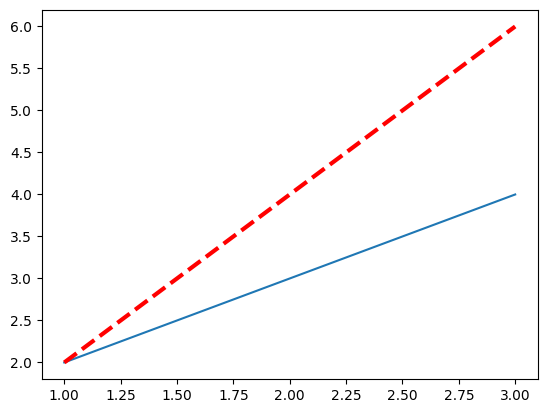

```python
import numpy as np
import matplotlib.pyplot as plt

x1 = np.array([1, 2, 3])

# 第1条线：y = x + 1
y1 = x1 + 1
plt.plot(x1, y1)  # 使用默认参数绘制

# 第2条线：y = x*2
y2 = x1*2

#  color为颜色；linewidth为线宽，单位为像素；linestyle为线型，默认为实 线，“--”表示虚线

plt.plot(x1, y2, color='red', linewidth=3, linestyle='--')

plt.show()
```